# World of RNA Binding Proteins and Genomic Annotations: A Python Data Visualization Project

### Matriculation Number: 22108480

### Author: Afzal Sufiya

### SS2023

## Loading Libraries and data

```python
import pandas as pd
import matplotlib.pyplot as plt
import numpy as np
import seaborn as sns
# loading dataset
signals = pd.read_csv('sig.csv')
annotation = pd.read_csv('anno.csv')
```

## 1. RNA Binding Protein Signal Visualization

Three alternative visualizations of the same artificial data has been created. All three visualizations show the same fictitious genomic annotations together with fictitious RNA binding protein data.

Two different datasets are used for this task:

- `anno.csv`
- `sig.csv`

Each visualization integrates transcript structures and protein signal data, using different plotting techniques:

- Version 1: Displayed signals in separate tracks for clarity.
- Version 2: Combined signals in stacked layers.
- Version 3: Overlaid signals for a compact view.

All visualizations were created using `pandas`, `numpy`, `matplotlib`, and `seaborn`, and include comments explaining each step of the code.

```python
 #creating variables for different signal data for plotting
p1 = signals['P1']

p2 = signals['P2']

p3 = signals['P3']

p4 = signals['P4']
```

### 1.1 : Version 1

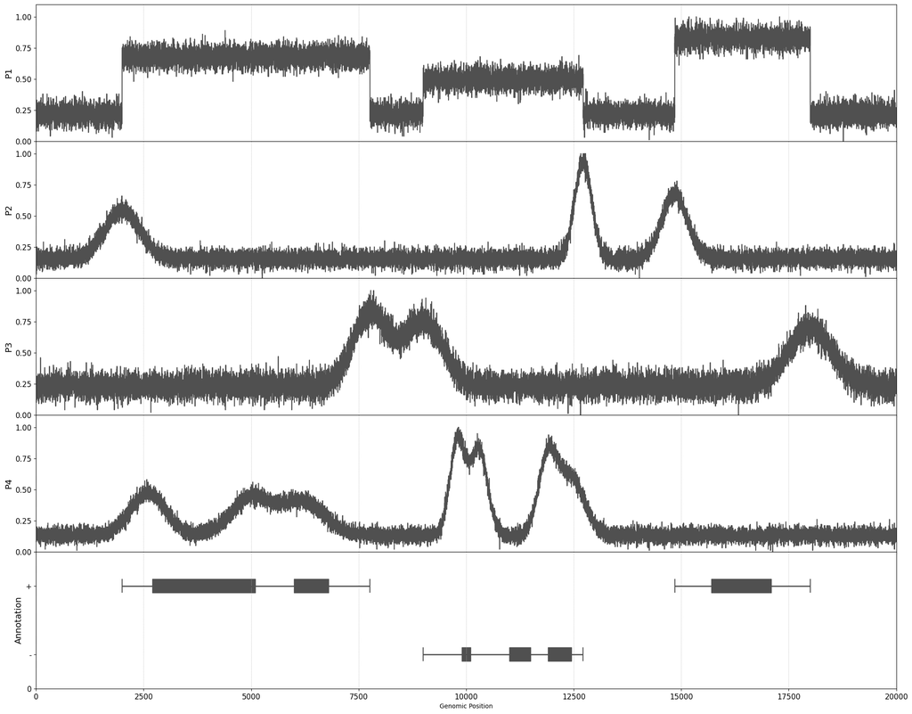

```python
fig , (plot1,plot2,plot3,plot4,plot5) = plt.subplots(5,1,sharex = True,figsize=(25,20), facecolor = 'w') #customizing subplots

plot1.grid(axis ='x',linestyle = 'dotted') # customiozing gridlines
plot1.plot(p1,c = '#505050') #color to the plot
plot1.set_ylabel('P1', size=14) # labeling
plot1.set_ylim(0, 1.1) #setting limits for y axis
plot1.set_yticks([0, 0.25, 0.50, 0.75, 1])  #Setting y-axis ticks for plot1
plot1.set_yticklabels(['0.00', '0.25', '0.50', '0.75', '1.00'], fontsize=12)  # setting y-axis tick labels for plot1

#similarly, other plots also follow the same procedures
plot2.grid(axis = 'x',linestyle ='dotted')
plot2.plot(p2,c = '#505050')
plot2.set_ylabel('P2', size=14)
plot2.set_ylim(0, 1.1)
plot2.set_yticks([0, 0.25, 0.50, 0.75, 1])
plot2.set_yticklabels(['0.00', '0.25', '0.50', '0.75', '1.00'], fontsize=12)

plot3.grid(axis = 'x',linestyle ='dotted')
plot3.plot(p3,c = '#505050')
plot3.set_ylabel('P3', size=14)
plot3.set_ylim(0, 1.1)
plot3.set_yticks([0, 0.25, 0.50, 0.75, 1])
plot3.set_yticklabels(['0.00', '0.25', '0.50', '0.75', '1.00'], fontsize=12)


plot4.grid(axis = 'x',linestyle ='dotted')
plot4.plot(p4,c = '#505050')
plot4.set_ylabel('P4', size=14)
plot4.set_ylim(0, 1.1)
plot4.set_yticks([0, 0.25, 0.50, 0.75, 1])
plot4.set_yticklabels(['0.00', '0.25', '0.50', '0.75', '1.00'], fontsize=12)


plt.margins(0) #closing down the white spaces that may occur


# Drawing the gene annotation data using line plot method with varied line widths
for x_1 , x_2 in zip(annotation.start[(annotation.name=='geneA') & (annotation.type=='exon')].values ,annotation.stop[(annotation.name=='geneA') & (annotation.type=='exon')].values):
    plot5.add_patch(plt.Rectangle((x_1,0.7),x_2-x_1,0.1,color='#505050')) # for gene A start, exon stop, exon values are taken
for x_1 , x_2 in zip(annotation.start[(annotation.name=='geneB') & (annotation.type=='exon')].values ,annotation.stop[(annotation.name=='geneB') & (annotation.type=='exon')].values):
    plot5.add_patch(plt.Rectangle((x_1,0.2),x_2-x_1,0.1,color='#505050')) # for gene B start, exon stop, exon values are take
for x_1 , x_2 in zip(annotation.start[(annotation.name=='geneC') & (annotation.type=='exon')].values ,annotation.stop[(annotation.name=='geneC') & (annotation.type=='exon')].values):
    plot5.add_patch(plt.Rectangle((x_1,0.7),x_2-x_1,0.1,color='#505050')) # for gene c start, exon stop, exon values are take
plot5.autoscale() # which axis to operate on: default is both
plot5.hlines(y=0.75, xmin=annotation.start[(annotation.name=='geneA') & (annotation.type=='transcript')].values, xmax=annotation.stop[(annotation.name=='geneA') & (annotation.type=='transcript')].values, linewidth=2, color='#505050')  # Drawing horizontal lines for Gene A with the given specs
plot5.vlines(x =annotation .start[(annotation.name=='geneA') & (annotation.type=='transcript')].values,ymin=0.7,ymax=0.8,color='#505050' ) #Drawing vertical lines for Gene A with the given specs
plot5.vlines(x = annotation.stop[(annotation.name=='geneA') & (annotation.type=='transcript')].values,ymin=0.7,ymax=0.8,color='#505050')
plot5.hlines(y=0.25, xmin=annotation.start[(annotation.name=='geneB') & (annotation.type=='transcript')].values, xmax=annotation.stop[(annotation.name=='geneB') & (annotation.type=='transcript')].values, linewidth=2, color='#505050')
plot5.vlines(x = annotation.start[(annotation.name=='geneB') & (annotation.type=='transcript')].values,ymin=0.20,ymax=0.30,color='#505050' )
plot5.vlines(x = annotation.stop[(annotation.name=='geneB') & (annotation.type=='transcript')].values,ymin=0.20,ymax=0.30,color='#505050')
plot5.hlines(y=0.75, xmin=annotation.start[(annotation.name=='geneC') & (annotation.type=='transcript')].values, xmax=annotation.stop[(annotation.name=='geneC') & (annotation.type=='transcript')].values, linewidth=2, color='#505050')
plot5.vlines(x = annotation.start[(annotation.name=='geneC') & (annotation.type=='transcript')].values,ymin=0.7,ymax=0.8,color='#505050' )
plot5.vlines(x = annotation.stop[(annotation.name=='geneC') & (annotation.type=='transcript')].values,ymin=0.7,ymax=0.8,color='#505050')

plot5.set_xticks(np.arange(0,20001,2500)) # setting x axis limits
plot5.set_facecolor('w') #Setting background color to white
plt.gca().set_yticks([0,0.25,0.75,1]) #setting y axis ticks
plt.gca().set_yticklabels([0,'-', '+',''], size=12) #setting y axis ticks labels
plt.grid(axis = 'x', linestyle ='dotted') #customising grid lines for x axis
plt.subplots_adjust(wspace =0, hspace =0) #deleting the horizontal and wide space between the plots
plt.xlabel("Genomic Position")
plt.ylabel('Annotation', size=14)
plt.rcParams["axes.edgecolor"] = "black" #border line
plt.xlim(0, 20000)
plt.xticks(size=12)
plt.show()
```

### 1.2 : Version 2

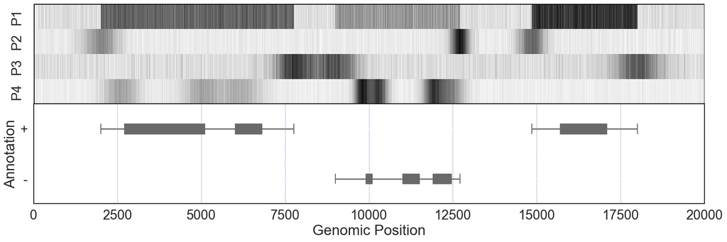

```python
fig, gs = plt.subplots(2, 1, figsize=(20, 6), gridspec_kw={'height_ratios': [1, 1], 'hspace': 0}, facecolor='w') #for subplots

#signals heatmap using seaborn
sns.set(font_scale=2)
heat = sns.heatmap(signals.T, cmap="Greys", xticklabels=2500, ax=gs[0], cbar=False) #customizing heatmap plot
heat.tick_params(labelbottom=False, size=14) #disabling legends
heat.axes.get_xaxis().set_visible(False)
heat.grid(axis='x', linestyle='dotted', color='black')
heat.set_xlim(0, 20000)
heat.add_artist(plt.Rectangle((0, 0), 20000, signals.shape[1], edgecolor='black', facecolor='none', linewidth=2)) #custpmizing plot


#annotation Data plotted (similar to previous version)
plot5 = gs[1]
for x_1, x_2 in zip(annotation.start[(annotation.name == 'geneA') & (annotation.type == 'exon')].values,
                    annotation.stop[(annotation.name == 'geneA') & (annotation.type == 'exon')].values):
    plot5.add_patch(plt.Rectangle((x_1, 0.7), x_2 - x_1, 0.1, color='dimgrey'))
for x_1, x_2 in zip(annotation.start[(annotation.name == 'geneB') & (annotation.type == 'exon')].values,
                    annotation.stop[(annotation.name == 'geneB') & (annotation.type == 'exon')].values):
    plot5.add_patch(plt.Rectangle((x_1, 0.2), x_2 - x_1, 0.1, color='dimgrey'))
for x_1, x_2 in zip(annotation.start[(annotation.name == 'geneC') & (annotation.type == 'exon')].values,
                    annotation.stop[(annotation.name == 'geneC') & (annotation.type == 'exon')].values):
    plot5.add_patch(plt.Rectangle((x_1, 0.7), x_2 - x_1, 0.1, color='dimgrey'))
plot5.autoscale()
plot5.hlines(y=0.75, xmin=annotation.start[(annotation.name == 'geneA') & (annotation.type == 'transcript')].values,
           xmax=annotation.stop[(annotation.name == 'geneA') & (annotation.type == 'transcript')].values, linewidth=2,
           color='dimgrey')
plot5.vlines(x=annotation.start[(annotation.name == 'geneA') & (annotation.type == 'transcript')].values, ymin=0.7,
           ymax=0.8, color='dimgrey')
plot5.vlines(x=annotation.stop[(annotation.name == 'geneA') & (annotation.type == 'transcript')].values, ymin=0.7,
           ymax=0.8, color='dimgrey')
plot5.hlines(y=0.25, xmin=annotation.start[(annotation.name == 'geneB') & (annotation.type == 'transcript')].values,
           xmax=annotation.stop[(annotation.name == 'geneB') & (annotation.type == 'transcript')].values, linewidth=2,
           color='dimgrey')
plot5.vlines(x=annotation.start[(annotation.name == 'geneB') & (annotation.type == 'transcript')].values, ymin=0.2,
           ymax=0.3, color='dimgrey')
plot5.vlines(x=annotation.stop[(annotation.name == 'geneB') & (annotation.type == 'transcript')].values, ymin=0.2,
           ymax=0.3, color='dimgrey')
plot5.hlines(y=0.75, xmin=annotation.start[(annotation.name == 'geneC') & (annotation.type == 'transcript')].values,
           xmax=annotation.stop[(annotation.name == 'geneC') & (annotation.type == 'transcript')].values, linewidth=2,
           color='dimgrey')
plot5.vlines(x=annotation.start[(annotation.name == 'geneC') & (annotation.type == 'transcript')].values, ymin=0.7,
           ymax=0.8, color='dimgrey')
plot5.vlines(x=annotation.stop[(annotation.name == 'geneC') & (annotation.type == 'transcript')].values, ymin=0.7,
           ymax=0.8, color='dimgrey')
plot5.set_xticks(np.arange(0, 20001, 2500))
plot5.set_facecolor('w')
plot5.grid(axis='x', linestyle='dotted', color='b')
plot5.set_xlabel('Genomic Position')
plot5.set_ylabel('Annotation')
plot5.set_yticks([0, 0.25, 0.75, 1])
plot5.set_yticklabels(['', '-', '+', ''])
plot5.spines['top'].set_color('black') #setting spines to set border colors
plot5.spines['bottom'].set_color('black')
plot5.spines['left'].set_color('black')
plot5.spines['right'].set_color('black')

plt.show()
```

### 1.3 : Version 3

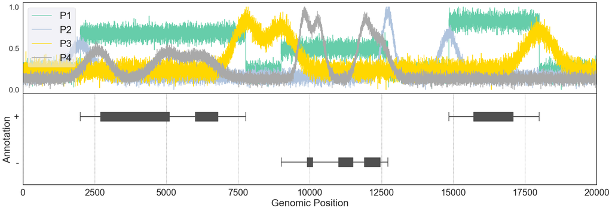

```python
fig, (plot, plot5) = plt.subplots(2,1, sharex = True, figsize=(25,8), facecolor='w') #for subplotting

#signals data plotted
plot.grid(axis='x', linestyle='dotted', color='#505050')
plot.plot(p1, c='mediumaquamarine', label='P1')  # Add label for P1
plot.plot(p2, c='lightsteelblue', label='P2')    # Add label for P2
plot.plot(p3, c='gold', label='P3')              # Add label for P3
plot.plot(p4, c='darkgray', label='P4')          # Add label for P4
plot.set_facecolor('w')
plot.grid(linestyle='dotted', color='w')
plot.set_xlim(0, len(p1))
plot.set_yticks([0, 0.50, 1])
plot.set_yticklabels(['0.0', '0.5', '1.0'], fontsize=18)
plot.legend(loc='upper left', fontsize=24, framealpha=0.6) #setting legends

#annotation data plotted (similar to previous versions)
for x_1 , x_2 in zip(annotation.start[(annotation.name=='geneA') & (annotation.type=='exon')].values ,annotation.stop[(annotation.name=='geneA') & (annotation.type=='exon')].values):
    plot5.add_patch(plt.Rectangle((x_1,0.7),x_2-x_1,0.1,color='#505050'))
for x_1 , x_2 in zip(annotation.start[(annotation.name=='geneB') & (annotation.type=='exon')].values ,annotation.stop[(annotation.name=='geneB') & (annotation.type=='exon')].values):
    plot5.add_patch(plt.Rectangle((x_1,0.2),x_2-x_1,0.1,color='#505050'))
for x_1 , x_2 in zip(annotation.start[(annotation.name=='geneC') & (annotation.type=='exon')].values ,annotation.stop[(annotation.name=='geneC') & (annotation.type=='exon')].values):
    plot5.add_patch(plt.Rectangle((x_1,0.7),x_2-x_1,0.1,color='#505050'))
plot5.autoscale()
plot5.hlines(y=0.75, xmin=annotation.start[(annotation.name=='geneA') & (annotation.type=='transcript')].values, xmax=annotation.stop[(annotation.name=='geneA') & (annotation.type=='transcript')].values, linewidth=2, color='#505050')
plot5.vlines(x = annotation.start[(annotation.name=='geneA') & (annotation.type=='transcript')].values,ymin=0.7,ymax=0.8,color='#505050' )
plot5.vlines(x = annotation.stop[(annotation.name=='geneA') & (annotation.type=='transcript')].values,ymin=0.7,ymax=0.8,color='#505050')
plot5.hlines(y=0.25, xmin=annotation.start[(annotation.name=='geneB') & (annotation.type=='transcript')].values, xmax=annotation.stop[(annotation.name=='geneB') & (annotation.type=='transcript')].values, linewidth=2, color='#505050')
plot5.vlines(x = annotation.start[(annotation.name=='geneB') & (annotation.type=='transcript')].values,ymin=0.2,ymax=0.3,color='#505050' )
plot5.vlines(x = annotation.stop[(annotation.name=='geneB') & (annotation.type=='transcript')].values,ymin=0.2,ymax=0.3,color='#505050')
plot5.hlines(y=0.75, xmin=annotation.start[(annotation.name=='geneC') & (annotation.type=='transcript')].values, xmax=annotation.stop[(annotation.name=='geneC') & (annotation.type=='transcript')].values, linewidth=2, color='#505050')
plot5.vlines(x = annotation.start[(annotation.name=='geneC') & (annotation.type=='transcript')].values,ymin=0.7,ymax=0.8,color='#505050' )
plot5.vlines(x = annotation.stop[(annotation.name=='geneC') & (annotation.type=='transcript')].values,ymin=0.7,ymax=0.8,color='#505050')
plot5.set_xticks(np.arange(0,20001,2500))
plot5.set_facecolor('w')
plt.gca().set_yticks([0,0.25,0.75,1])

plot5.set_xlim(0, len(p1))
plt.gca().set_yticklabels(['','-', '+',''])
plt.grid(axis='x', linestyle ='dotted', color='#505050')
plt.subplots_adjust(wspace =0, hspace =0)
plt.xlabel('Genomic Position')
plt.ylabel('Annotation')
plt.rcParams["axes.edgecolor"] = "black" #border with color black
```

### 1.4 : Discussion

The exact properties of our data and the insights we wish to communicate will influence the visualization strategy we use. Each version has pros and cons, therefore we may think about combining components from other versions to produce the best possible depiction of our data.

#### Version 1

**Pros**

1. Separates the data into five subplots(easy to compare different aspects of the data)
2. Allows customization of each subplot individually
3. Providing clear annotations.

**Cons**

1. Plots may appear crowded(hard to interpret the overall patterns)
2. Annotations seems chalenging to visualize accurately.

#### Version 2

**Pros**

1. Heatmap provides signal intensities(easy to identify patterns and trends)
2. Adding annotation data in a single plot allows for a comprehensive view of the data.
3. Provides a clear representation of gene locations.

**Cons**

1. Not good choice to show signal intensity if the data contains sparse values.
2. Gene annotation could overlap heatmap(Hard to distinguish individual annotations)

#### Version 3

**Pros**

1. The line plot, plotted with all signals together mkae easy to compare all signals.
2. Adding annotation data in a single plot provides good view of the data.
3. Less subplots compare to Version 1(Make visualization less cluttered).

**Cons**

1. Not ideal for visualizing dense signal data(as lines may overlap and obscure patterns)
2. The annotations might become visually cluttered if there are too many genes or exons.

## 2. Multi-Panel Figure

In this task, a composite figure with three panels was created by combining:

- `scatter.csv` contains the data needed to create the shown scatter plot
- `bar.csv` contains the data needed to create the shown bar plot.
- A genomic annotation + RNA binding protein signal plot reused from Task 1

The combined figure effectively integrates different types of visual data to provide a comprehensive view of the dataset.

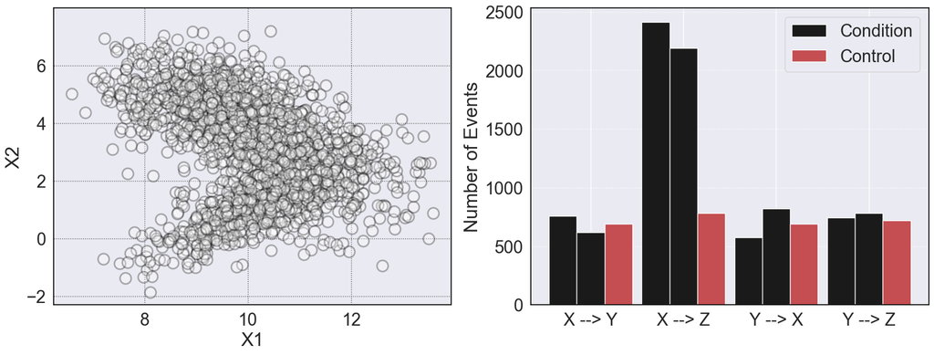

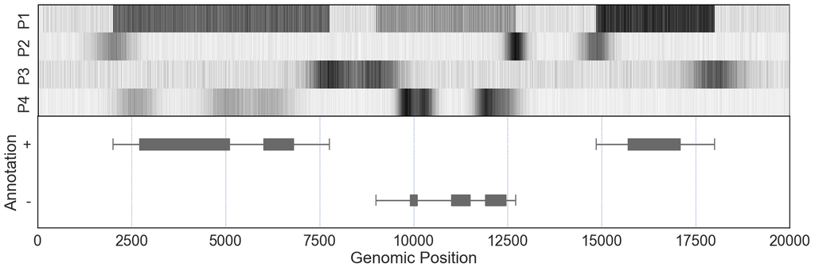

```python
# Loading data
scatter = pd.read_csv('scttr.csv')
barplot = pd.read_csv('bar.csv')

# Increasing the figure size & background
fig=plt.figure(figsize=(20, 15), facecolor='w')

# Scatter plot
SCATERPLOT = plt.subplot(221)  # 1 row, 2 columns, first plot
SCATERPLOT.scatter('x1', 'x2', data=scatter, c='white', edgecolor='black', s=200, alpha=.3, linewidth=2) #customizing scatter plot
SCATERPLOT.grid(linestyle ='dotted', color='#505050', zorder=1) #gridlines
SCATERPLOT.set_ylim(-2.3, 8)
SCATERPLOT.set_xlabel('X1')
SCATERPLOT.set_ylabel('X2')
SCATERPLOT.set_yticks([i for i in range(-2, 8, 2)])
SCATERPLOT.set_xticks([8,10,12])


# Bar plot
ind = [i for i in range(len(barplot))]
width = 0.3  # setting width of the bars
BARPLOT = plt.subplot(222)  # 1 row, 2 columns, second plot
yvals = barplot.iloc[:, 1].values
rects1 = BARPLOT.bar(ind, yvals, width, color='k', edgecolor='white')
zvals = barplot.iloc[:, 2].values
rects2 = BARPLOT.bar([i + width for i in ind], zvals, width, color='k', edgecolor='white')
kvals = barplot.iloc[:, 3].values
rects3 = BARPLOT.bar([i + width * 2 for i in ind], kvals, width, color='r', edgecolor='white')


BARPLOT.set_xticks([i + width for i in ind])
BARPLOT.set_xticklabels(('X --> Y', 'X --> Z', 'Y --> X', 'Y --> Z'))
BARPLOT.set_ylabel('Number of Events')
plt.legend((rects1[0], rects3[0]), ('Condition', 'Control'))
plt.rcParams["axes.edgecolor"] = "black"  # border lines
plt.grid(axis='y', linestyle='dotted')  # grid lines and customization


fig, gs = plt.subplots(2, 1, figsize=(20, 6), gridspec_kw={'height_ratios': [1, 1], 'hspace': 0}, facecolor='w')

#signals heatmap using seaborn
sns.set(font_scale=2)
heat = sns.heatmap(signals.T, cmap="Greys", xticklabels=2500, ax=gs[0], cbar=False)
heat.tick_params(labelbottom=False)
heat.axes.get_xaxis().set_visible(False)
heat.grid(axis='x', linestyle='dotted', color='w')
heat.set_xlim(0, 20000)
heat.add_artist(plt.Rectangle((0, 0), 20000, signals.shape[1], edgecolor='black', facecolor='none', linewidth=2))

plot5 = gs[1]
#annotation Data plotted(similar to previous versions)
for x_1, x_2 in zip(annotation.start[(annotation.name == 'geneA') & (annotation.type == 'exon')].values,
                    annotation.stop[(annotation.name == 'geneA') & (annotation.type == 'exon')].values):
    plot5.add_patch(plt.Rectangle((x_1, 0.7), x_2 - x_1, 0.1, color='dimgrey'))
for x_1, x_2 in zip(annotation.start[(annotation.name == 'geneB') & (annotation.type == 'exon')].values,
                    annotation.stop[(annotation.name == 'geneB') & (annotation.type == 'exon')].values):
    plot5.add_patch(plt.Rectangle((x_1, 0.2), x_2 - x_1, 0.1, color='dimgrey'))
for x_1, x_2 in zip(annotation.start[(annotation.name == 'geneC') & (annotation.type == 'exon')].values,
                    annotation.stop[(annotation.name == 'geneC') & (annotation.type == 'exon')].values):
    plot5.add_patch(plt.Rectangle((x_1, 0.7), x_2 - x_1, 0.1, color='dimgrey'))
plot5.autoscale()
plot5.hlines(y=0.75, xmin=annotation.start[(annotation.name == 'geneA') & (annotation.type == 'transcript')].values,
           xmax=annotation.stop[(annotation.name == 'geneA') & (annotation.type == 'transcript')].values, linewidth=2,
           color='dimgrey')
plot5.vlines(x=annotation.start[(annotation.name == 'geneA') & (annotation.type == 'transcript')].values, ymin=0.7,
           ymax=0.8, color='dimgrey')
plot5.vlines(x=annotation.stop[(annotation.name == 'geneA') & (annotation.type == 'transcript')].values, ymin=0.7,
           ymax=0.8, color='dimgrey')
plot5.hlines(y=0.25, xmin=annotation.start[(annotation.name == 'geneB') & (annotation.type == 'transcript')].values,
           xmax=annotation.stop[(annotation.name == 'geneB') & (annotation.type == 'transcript')].values, linewidth=2,
           color='dimgrey')
plot5.vlines(x=annotation.start[(annotation.name == 'geneB') & (annotation.type == 'transcript')].values, ymin=0.2,
           ymax=0.3, color='dimgrey')
plot5.vlines(x=annotation.stop[(annotation.name == 'geneB') & (annotation.type == 'transcript')].values, ymin=0.2,
           ymax=0.3, color='dimgrey')
plot5.hlines(y=0.75, xmin=annotation.start[(annotation.name == 'geneC') & (annotation.type == 'transcript')].values,
           xmax=annotation.stop[(annotation.name == 'geneC') & (annotation.type == 'transcript')].values, linewidth=2,
           color='dimgrey')
plot5.vlines(x=annotation.start[(annotation.name == 'geneC') & (annotation.type == 'transcript')].values, ymin=0.7,
           ymax=0.8, color='dimgrey')
plot5.vlines(x=annotation.stop[(annotation.name == 'geneC') & (annotation.type == 'transcript')].values, ymin=0.7,
           ymax=0.8, color='dimgrey')
plot5.set_xticks(np.arange(0, 20001, 2500))
plot5.set_facecolor('w')
plot5.grid(axis='x', linestyle='dotted', color='b')
plot5.set_xlabel('Genomic Position')
plot5.set_ylabel('Annotation')
plot5.set_yticks([0, 0.25, 0.75, 1])
plot5.set_yticklabels(['', '-', '+', ''])
plot5.spines['top'].set_color('black')
plot5.spines['bottom'].set_color('black')
plot5.spines['left'].set_color('black')
plot5.spines['right'].set_color('black')

plt.show()
```

# 3. 2-mer counts in data

### Task 3: 2-mer Occurrence Analysis in DNA Sequences

In this task, the file `seq.txt` was used, which contains DNA sequences with one sequence per line.

The goal was to analyze the positional distribution of 2-mers (subsequences of length 2) and visualize how frequently specific 2-mers occur at each position across all sequences.

For example, given the 2-mers `"xx"` and `"yy"` in the sequences:

TCTAAGGxxyyG

xxCGTGGyyCGT

TTTxxACCGyyG

AGCxxACAACyy

TAxxCAAyyAGT

The counts for each 2-mer by position would be:

- `"xx"`: `[1 0 1 2 0 0 0 1 0 0 0 0]`
- `"yy"`: `[0 0 0 0 0 0 0 2 0 2 1 0]`

Python code was provided to scan all sequences, count 2-mer occurrences at each position, and generate a figure illustrating these positional frequencies.

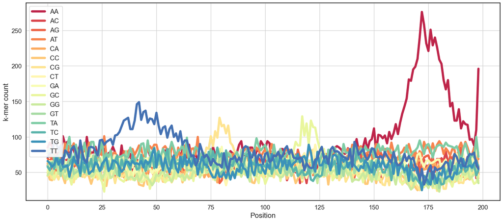

```python
#defining function to count 2-mers
def count_kmers(sequences, kmers):
    kmer_counts = {kmer: [] for kmer in kmers}
    k = len(kmers[0])

    for i in range(len(sequences[0]) - k + 1):
        for kmer in kmers:
            count = 0
            for sequence in sequences:
                count += sequence[i:i+k] == kmer
            kmer_counts[kmer].append(count)

    return kmer_counts

#reading sequences from the text file
filename = "seq.txt"
with open(filename, 'r') as file:
    sequences = [line.strip() for line in file]


kmers = ["AA", "AC", "AG", "AT", "CA", "CC", "CG", "CT", "GA", "GC", "GG", "GT", "TA", "TC", "TG", "TT"] #define the k-mers


kmer_counts = count_kmers(sequences, kmers) #count occurrences of the k-mers at each position

#setting the Seaborn style
sns.set(style="whitegrid")
sns.set_palette("bright")
sns.set_palette("Spectral", len(kmers))

fig, ax = plt.subplots(figsize=(19, 8)) #create line plots for each k-mer with broader figure size
for i, kmer in enumerate(kmers):
    counts = kmer_counts[kmer]
    non_zero_counts = [count if count >= 0 else None for count in counts]
    ax.plot(range(len(non_zero_counts)), non_zero_counts, label=kmer, linewidth=5.0)



#setting the axis labels and title
plt.xlabel('Position', fontsize=16)
plt.ylabel('k-mer count', fontsize=16)

#setting the size of the tick labels
ax.tick_params(axis='x', labelsize=14)
ax.tick_params(axis='y', labelsize=14)

ax.set_facecolor('white') #setting the background color to white

for spine in ax.spines.values():
    spine.set_color('black')

ax.legend(loc='upper left', framealpha=0.9, fontsize='large') #displaying the legend

plt.show()
```